# Project 2: House Sales in King County, USA

# ANOVA for Regression Models

```
## Analysis of Variance Table
##
## Model 1: price ~ grade + view + condition + waterfront + bedrooms + bathrooms
## Model 2: price ~ sqft_lot + sqft_living + sqft_above + sqft_living15 +
##     sqft_lot15
## Model 3: price ~ yr_built + yr_renovated
## Model 4: price ~ bedrooms + bathrooms + floors + grade + view + condition +
##     waterfront + sqft_living + sqft_lot + sqft_above + sqft_living15 +
##     sqft_lot15 + yr_built + yr_renovated + sqft_basement
## Model 5: price ~ view + bedrooms + bathrooms + sqft_living + sqft_lot +
##     waterfront + condition + grade + yr_built + yr_renovated +
##     sqft_living15 + sqft_lot15 + floors
##   Res.Df      RSS  Df Sum of Sq      F  Pr(>F)
## 1  21356 7.41e+14
## 2  21409 9.14e+14 -53 -1.73e+14  116.5 < 2e-16 ***
## 3  21412 1.73e+15  -3 -8.20e+14 9745.6 < 2e-16 ***
## 4  21344 5.98e+14  68  1.14e+15  595.7 < 2e-16 ***
## 5  21345 6.00e+14  -1 -1.38e+12   49.3 2.2e-12 ***
## ---
## Signif. codes:  0 '***' 0.001 '**' 0.01 '*' 0.05 '.' 0.1 ' ' 1
```

ANOVA shows us that models 2, 3, 4, and 5 are statistically significant and are good models for explaining the data/target variable. However, we know that the models might overfit the data, thus, we will do PCA/PCR and model evaluations to check if we can have the best model among them.

# Chapter 5 PCA/PCR

After using we trying to use linear model to predict the price in our dataset, we find out there are too many variables for our feature variables. We immediately think of PCA so that we can reduce the dimensionality of our feature variables. Since PCA only works on numerical variable, we decided to pick out all the numerical variables for running PCA. The speed is immediatly improved. We know PCA can also have the effects on saving data storage although in our case the size of this dataset is no way around huge. However, we find it is so fast to run PCA compared with using linear models. We decide to run PCA both with factor variables and without factor variables.

### PCA/PCR Without Factor

```
## Importance of components:
##                          PC1   PC2   PC3   PC4   PC5    PC6      PC7
## Standard deviation     1.819 1.268 1.040 0.648 0.555 0.5206 3.72e-15
## Proportion of Variance 0.473 0.230 0.155 0.060 0.044 0.0387 0.00e+00
## Cumulative Proportion  0.473 0.703 0.857 0.917 0.961 1.0000 1.00e+00
```

```
## Importance of components:
##                             PC1      PC2      PC3      PC4 PC5 PC6
## Standard deviation     2.88e+05 4.64e+04 1.69e+04 9.13e+02 506 384
## Proportion of Variance 9.71e-01 2.52e-02 3.35e-03 1.00e-05   0   0
## Cumulative Proportion  9.71e-01 9.97e-01 1.00e+00 1.00e+00   1   1
##                             PC7
## Standard deviation     4.12e-12
## Proportion of Variance 0.00e+00
## Cumulative Proportion  1.00e+00
```

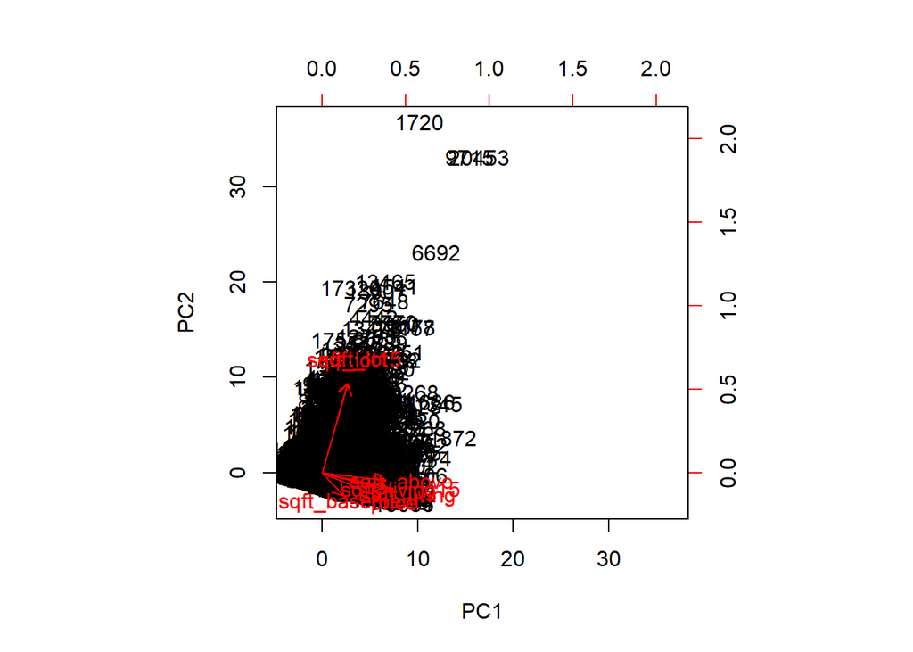

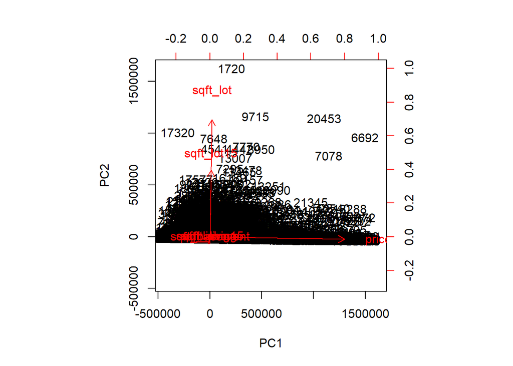

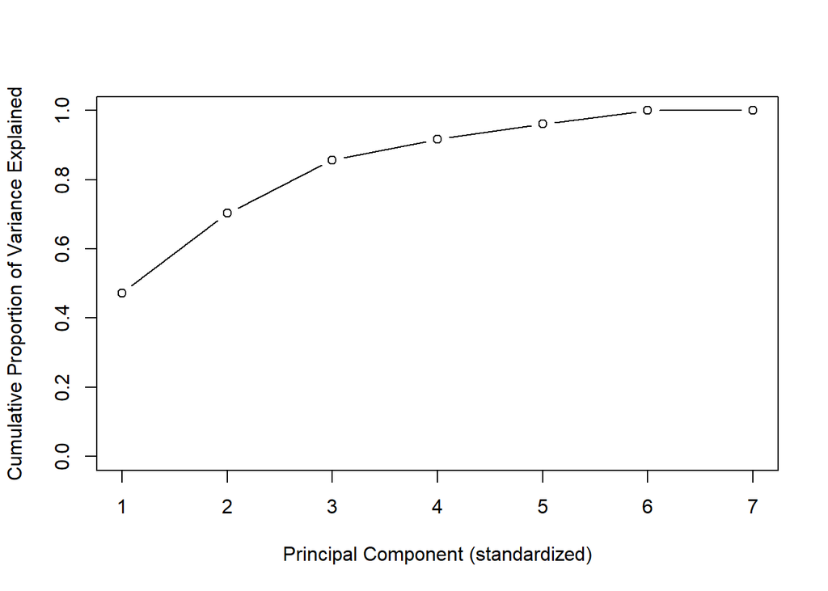

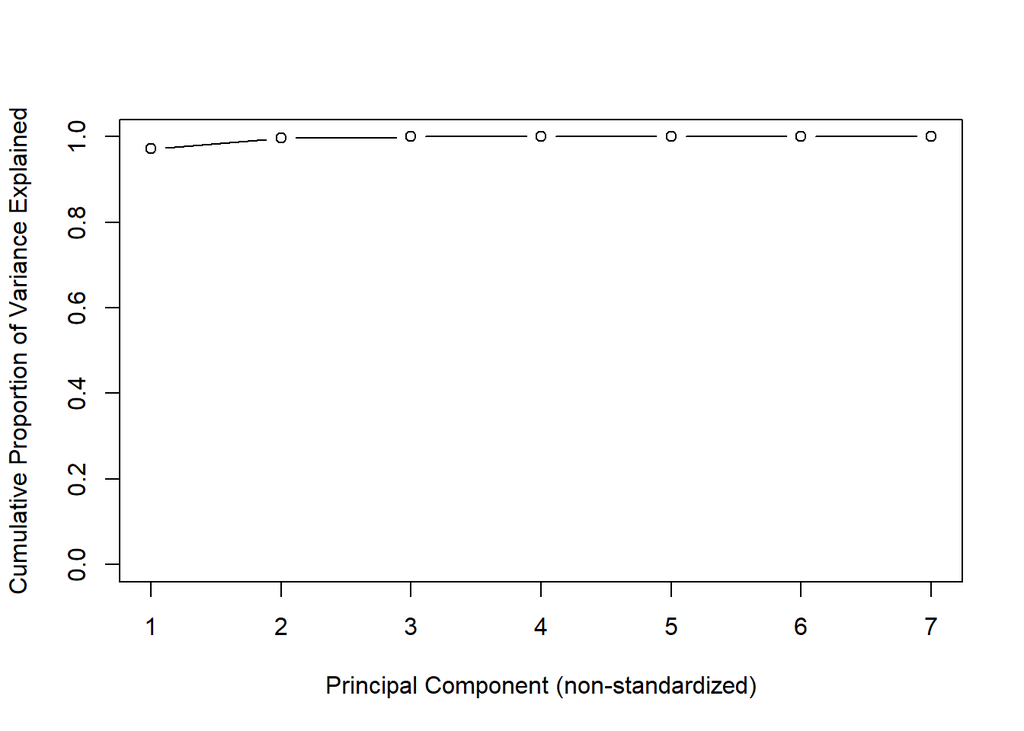

After PCA, we plotted out the cumulatice proportion of variance explained graph of the PCA test. The normalized graph shows that when we use 4 components here it will capture 90 percent of the variance of the data. On the other hand, for the non-normalized graph it shows only one component can capture almost 100 percent of the variance of the data which is unexpected. We think this is maybe because our variable are all closely related because their unit are the area of a house.

```
## Data:    X dimension: 21415 6
##  Y dimension: 21415 1
## Fit method: svdpc
## Number of components considered: 6
##
## VALIDATION: RMSEP
## Cross-validated using 10 random segments.
##        (Intercept)  1 comps  2 comps  3 comps  4 comps  5 comps  6 comps
## CV          287821   219486   208079   206981   206885   206752   206752
## adjCV       287821   219472   208075   206976   206880   206746   206745
##
## TRAINING: % variance explained
##        1 comps  2 comps  3 comps  4 comps  5 comps  6 comps
## X        46.53    72.39    90.31    95.46   100.00   100.00
## price    41.90    47.77    48.32    48.37    48.45    48.45
```

```
## Data:    X dimension: 21415 6
##  Y dimension: 21415 1
## Fit method: svdpc
## Number of components considered: 6
##
## VALIDATION: RMSEP
## Cross-validated using 10 random segments.
##        (Intercept)  1 comps  2 comps  3 comps  4 comps  5 comps  6 comps
## CV          287821   286273   286315   211081   206993   206774   206792
## adjCV       287821   286271   286311   211077   206988   206767   206780
##
## TRAINING: % variance explained
##        1 comps  2 comps  3 comps  4 comps  5 comps  6 comps
## X       88.320   99.921    99.98    99.99   100.00   100.00
## price    1.093    1.095    46.25    48.32    48.45    48.45
```

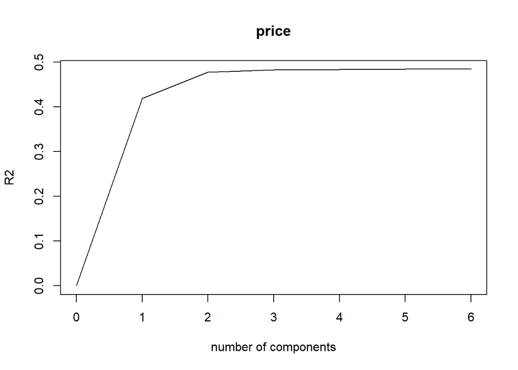

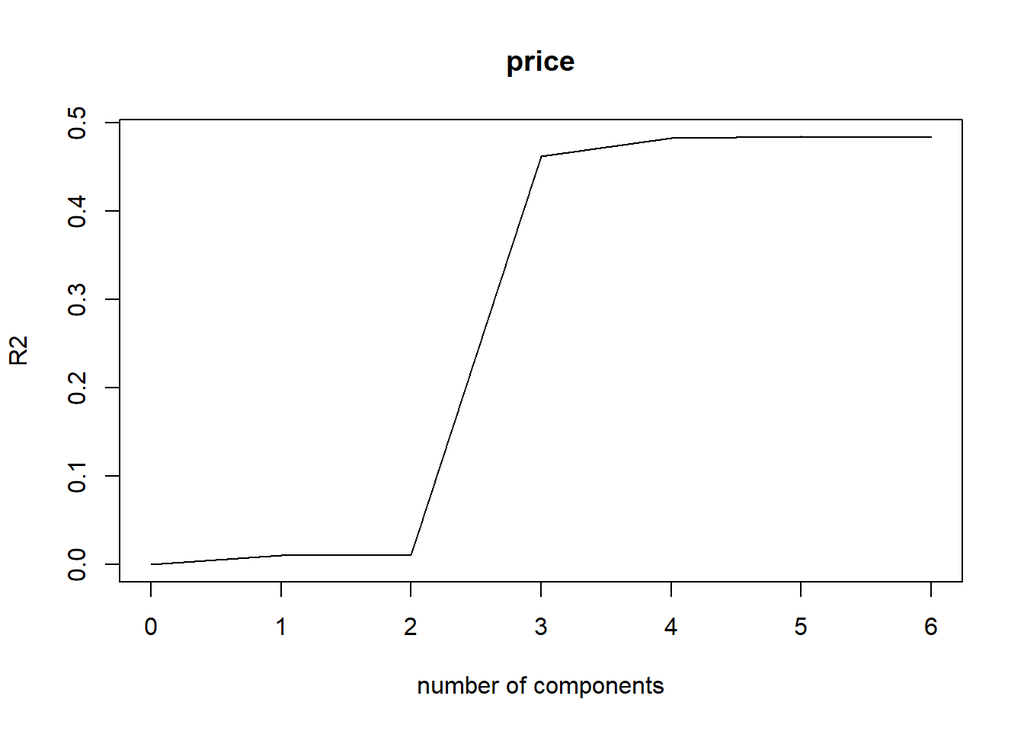

After using PCA test, we plan to use principal components regression model to fit our data to see if the model is improved compared with linear model we previously used. We look at the results and find if we only need to use 3 components to capture 90 percent of the feature variable variance and 48 percent of the prediction variable. We also run a validation plot for this PCR model and we see the r2 number is around 50 percent when we use 2 components. It mean using these 2 components and this model explains 50 percent of our data.

### PCA/PCR With Factor

This time we apply the PCA and PCR with factor variable included. We would like to see if there is any improvment in this new model.

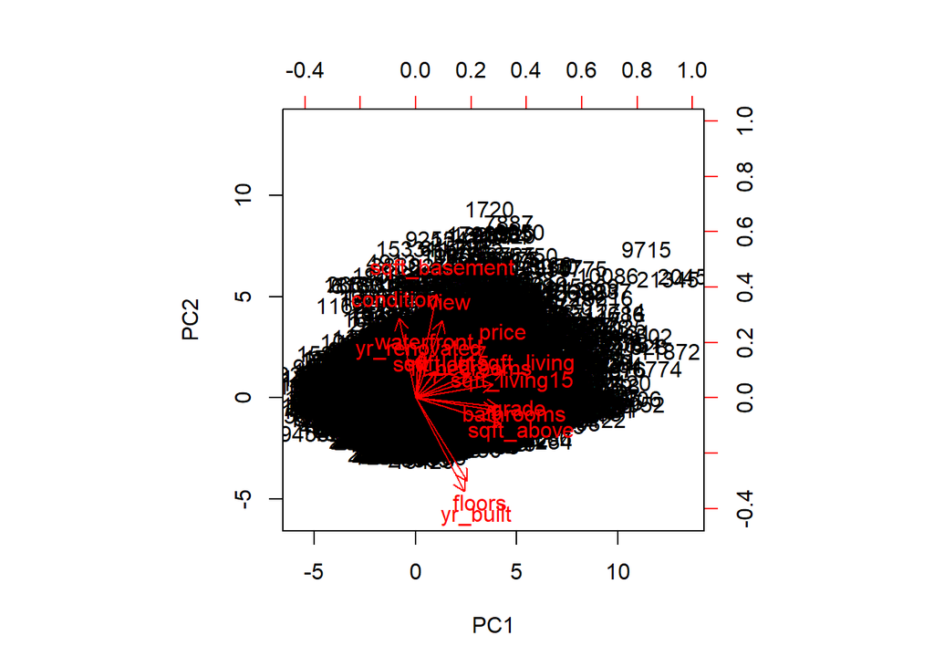

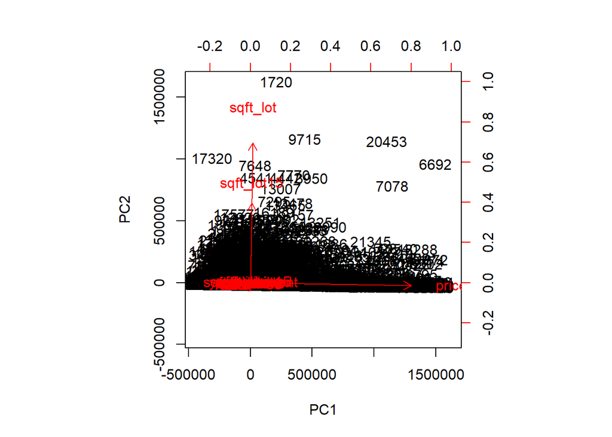

Although technicly we should not scale our data when we are using factor by using hamming distance, we still want to see if there is any difference before and after when we scale our data.

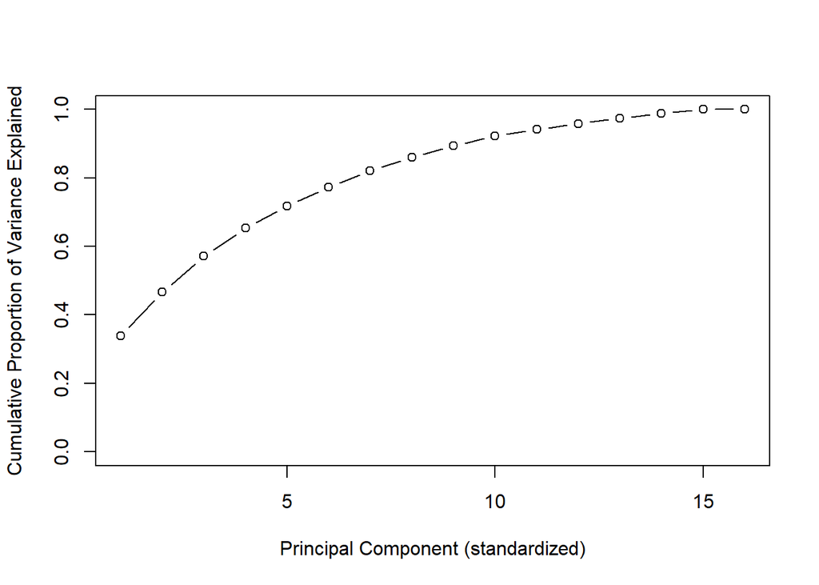

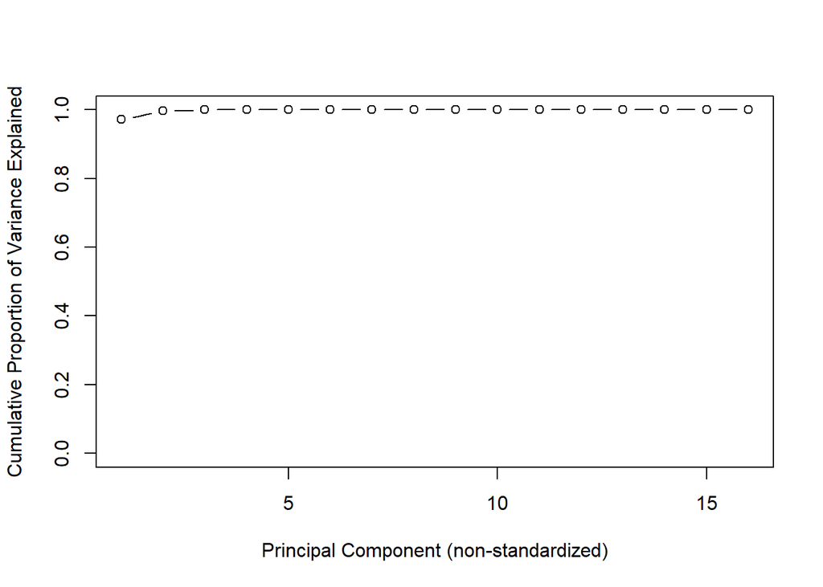

In this model, we see using 10 component we can capture 90 percent of variance of the data. However, if we not scale the data at all, only one variable will caputure almost 100 percent of the variance.

```
## Data:    X dimension: 21415 15
##  Y dimension: 21415 1
## Fit method: svdpc
## Number of components considered: 15
##
## VALIDATION: RMSEP
## Cross-validated using 10 random segments.
##        (Intercept)  1 comps  2 comps  3 comps  4 comps  5 comps  6 comps
## CV          287821   219426   203953   200688   198005   197926   193802
## adjCV       287821   219424   203945   200684   197998   197919   193789
##        7 comps  8 comps  9 comps  10 comps  11 comps  12 comps  13 comps
## CV      185899   185853   184996    176128    175325    174216    172717
## adjCV   185883   185842   184986    176119    175347    174253    172705
##        14 comps  15 comps
## CV       171577    171583
## adjCV    171564    171566
##
## TRAINING: % variance explained
##        1 comps  2 comps  3 comps  4 comps  5 comps  6 comps  7 comps
## X        32.96    45.88    57.01    65.71    72.56    78.25    82.97
## price    41.90    49.84    51.43    52.73    52.79    54.75    58.37
##        8 comps  9 comps  10 comps  11 comps  12 comps  13 comps  14 comps
## X        87.11    90.71     93.35     95.27     96.97     98.62    100.00
## price    58.38    58.78     62.64     62.97     63.44     64.08     64.56
##        15 comps
## X        100.00
## price     64.56
```

```
## Data:    X dimension: 21415 15
##  Y dimension: 21415 1
## Fit method: svdpc
## Number of components considered: 15
##
## VALIDATION: RMSEP
## Cross-validated using 10 random segments.
##        (Intercept)  1 comps  2 comps  3 comps  4 comps  5 comps  6 comps
## CV          287821   286277   286314   211060   206977   206738   199184
## adjCV       287821   286275   286310   211058   206973   206733   199179
##        7 comps  8 comps  9 comps  10 comps  11 comps  12 comps  13 comps
## CV      196607   183743   180170    180017    172566    172574    172490
## adjCV   196602   183737   180160    180016    172556    172565    172480
##        14 comps  15 comps
## CV       171563    171558
## adjCV    171552    171546
##
## TRAINING: % variance explained
##        1 comps  2 comps  3 comps  4 comps  5 comps  6 comps  7 comps
## X       88.320   99.921    99.98    99.99   100.00   100.00   100.00
## price    1.093    1.095    46.25    48.32    48.45    52.15    53.38
##        8 comps  9 comps  10 comps  11 comps  12 comps  13 comps  14 comps
## X       100.00   100.00    100.00    100.00    100.00    100.00    100.00
## price    59.29    60.87     60.94     64.12     64.12     64.16     64.56
##        15 comps
## X        100.00
## price     64.56
```

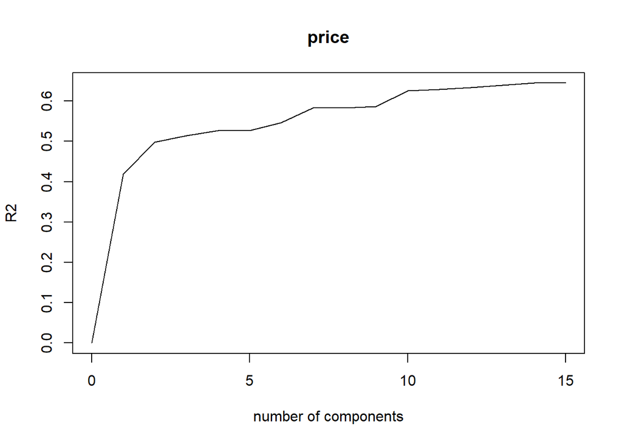

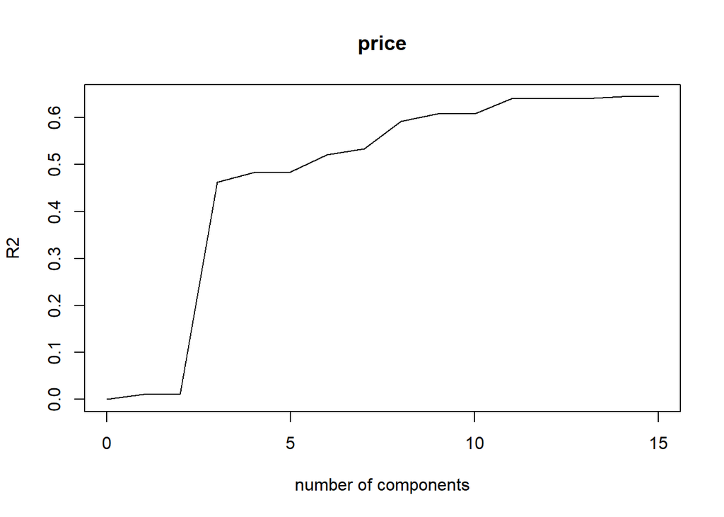

# Chapter 6 Model Evaluations

## K-fold Cross Validation

K-fold cross validation is used so that we can better compare the linear models we have. The order of this cross validation match with what we did before with the linear models, and we also add in backward selection and stepwise selection to do feature selections. By doing a 10 fold cross validation, we want to find out if the last linear model we did is the best one among them.

#### CV on Model 1

```
## Linear Regression
##
## 21415 samples
##     6 predictor
##
## No pre-processing
## Resampling: Cross-Validated (10 fold)
## Summary of sample sizes: 19273, 19274, 19274, 19274, 19273, 19274, ...
## Resampling results:
##
##   RMSE    Rsquared  MAE
##   187560  0.576     136801
##
## Tuning parameter 'intercept' was held constant at a value of TRUE
```

From the result, we can see that the R^2 is 0.576, which means 57.6% of price is being explained by the x variables, which contain the categorical variables that we think is relevant to price. We have a high RMSE and a high MAE score, which mean that this model might not be a good one, so we move on to the next model, and see if quantitative variables will help with creating a better model.

#### CV on Model 2

```
## Linear Regression
##
## 21415 samples
##     5 predictor
##
## No pre-processing
## Resampling: Cross-Validated (10 fold)
## Summary of sample sizes: 19273, 19274, 19274, 19274, 19273, 19274, ...
## Resampling results:
##
##   RMSE    Rsquared  MAE
##   206680  0.484     151435
##
## Tuning parameter 'intercept' was held constant at a value of TRUE
```

Unfortunately, based on the results we have, the R^2 value decrease from 0.576 to 0.484, when we change the variables to all quantitative variables. The RMSE value and the MAE also increase a lot, which means that this is not a good model for prediction.

#### CV on Model 3

```
## Linear Regression
##
## 21415 samples
##     2 predictor
##
## No pre-processing
## Resampling: Cross-Validated (10 fold)
## Summary of sample sizes: 19273, 19274, 19274, 19274, 19273, 19274, ...
## Resampling results:
##
##   RMSE    Rsquared  MAE
##   284537  0.0228    208884
##
## Tuning parameter 'intercept' was held constant at a value of TRUE
```

For model 3, this is definetly not a good model because the R^2 value is only 0.0228, which means only about 2% of price is being explained by the “year built” and “year renovated”. The RMSE and MAE values also increase from model 2 to model 3, thus, we believe this is not a good model to consider.

#### CV on Full Model

```
## Linear Regression
##
## 21415 samples
##    15 predictor
##
## No pre-processing
## Resampling: Cross-Validated (10 fold)
## Summary of sample sizes: 19273, 19274, 19274, 19274, 19273, 19274, ...
## Resampling results:
##
##   RMSE    Rsquared  MAE
##   168630  0.657     120982
##
## Tuning parameter 'intercept' was held constant at a value of TRUE
```

Then, we move to the full model excluding the zipcode, longitude and latitude variables, because these three variables have too many levels, and this will take too long for the model to run and they are not useful for predicting the price. We now have a R^2 value of 0.657, which means 65.7% of price is being explained by the x variables, and this increase in R^2 value make sense because the value should increase as we increase the variables in the model, and the RMSE and MAE values are the smallest values that we contain so far. However, considering the model might overfit the data, and the multicollinearity inside the model, we wanna do a backward selection and a stepwise selection to do feature selecting.

#### CV on Full Model with Backward Selection

```
## Reordering variables and trying again:
## Reordering variables and trying again:
## Reordering variables and trying again:
## Reordering variables and trying again:
## Reordering variables and trying again:
## Reordering variables and trying again:
```

```
## Linear Regression with Backwards Selection
##
## 21415 samples
##    15 predictor
##
## No pre-processing
## Resampling: Cross-Validated (10 fold)
## Summary of sample sizes: 19273, 19274, 19274, 19274, 19273, 19274, ...
## Resampling results across tuning parameters:
##
##   nvmax  RMSE    Rsquared  MAE
##    1     252574  0.217     184436
##    2     248885  0.238     181764
##    3     238682  0.302     175373
##    4     225012  0.384     165297
##    5     218437  0.419     161664
##    6     204390  0.494     149016
##    7     201551  0.507     147737
##    8     195696  0.536     143663
##    9     193221  0.547     140962
##   10     192255  0.552     140047
##   11     191873  0.554     139816
##   12     185986  0.582     135153
##   13     183841  0.592     133534
##   14     182901  0.596     132960
##   15     181647  0.602     132103
##
## RMSE was used to select the optimal model using the smallest value.
## The final value used for the model was nvmax = 15.
```

For backward selection, it suggests us to use to model with the most variables we have, which means run a full model, since the RMSE will be the smallest. However, a full model is likely to overfit the data.

#### CV on Full Model with Stepwise Selection

```
## Reordering variables and trying again:
## Reordering variables and trying again:
## Reordering variables and trying again:
## Reordering variables and trying again:
## Reordering variables and trying again:
## Reordering variables and trying again:
```

```
## Linear Regression with Stepwise Selection
##
## 21415 samples
##    15 predictor
##
## No pre-processing
## Resampling: Cross-Validated (10 fold)
## Summary of sample sizes: 19273, 19274, 19274, 19274, 19273, 19274, ...
## Resampling results across tuning parameters:
##
##   nvmax  RMSE    Rsquared  MAE
##    1     252574  0.217     184436
##    2     248885  0.238     181764
##    3     246027  0.253     179660
##    4     244684  0.259     178191
##    5     234773  0.322     171927
##    6     204010  0.496     149168
##    7     201049  0.510     147741
##    8     197818  0.525     145497
##    9     192301  0.552     139904
##   10     261588  0.164     189834
##   11     245300  0.254     178632
##   12     202450  0.492     147720
##   13     190756  0.554     138232
##   14     181719  0.601     132753
##   15     180890  0.605     132013
##
## RMSE was used to select the optimal model using the smallest value.
## The final value used for the model was nvmax = 15.
```

By doing a subset selection, the results show the significancy of each variable in every model (this part takes too many spaces, therefore not including in the html file). We can consider excluding variables without the asterick because this mean the variables are not significant. Compare the result with the linear model we did before, we can consider excluding “sqft_lot”.

#### CV on a feature selected model using stepwise selection

```
## Linear Regression
##
## 21415 samples
##    14 predictor
##
## No pre-processing
## Resampling: Cross-Validated (10 fold)
## Summary of sample sizes: 19273, 19274, 19274, 19274, 19273, 19274, ...
## Resampling results:
##
##   RMSE    Rsquared  MAE
##   168637  0.657     120981
##
## Tuning parameter 'intercept' was held constant at a value of TRUE
```

As the result shown above, the R^2 is 0.657 which is the same with the full model, and the RMSE only increase a little, and MAE decreases, therefore, we can consider this model is better than the full model.

#### CV on Model 5

```
## Linear Regression
##
## 21415 samples
##    13 predictor
##
## No pre-processing
## Resampling: Cross-Validated (10 fold)
## Summary of sample sizes: 19273, 19274, 19274, 19274, 19273, 19274, ...
## Resampling results:
##
##   RMSE    Rsquared  MAE
##   168793  0.656     121316
##
## Tuning parameter 'intercept' was held constant at a value of TRUE
```

We then did the feature selections based on the significancy in the linear models and research. The results show that this model has R^2 of 0.656, RMSE of 168793 and MAE of 121316. The R^2 value is high and the RMSE and MAE values don’t increase a lot, compare to the models before.

#### Table for Cross Validation

```
##                                         RMSE   RSquared        MAE
## Model 1                           187560.000      0.576 136801.000
## Model 2                           206680.000      0.484 151435.000
## Model 3                           284537.000      0.023 208884.000
## Full Model                        168630.000      0.657 120982.000
## Model based on Stepwise Selection 168637.000      0.657 120981.000
## Significant feature Model         168793.000      0.656 121316.000
```

Based on the table, we can see the model based on stepwise selection is the best model that we obtain so far. The model contains 14 variables, which matches the result with PCA/PCR that a model with 14 variables will fully explain y variable when scaled. The model also has a high R^2 value of 0.657, which means 65.7% of price is being explained by the x variables, and the RMSE and MAE values don’t increase a lot compare to the full model. We don’t consider the full model because there is a chance that we might overfit the data. We don’t consider the last model because this model contains 13 variables, it doesn’t fully explained the y variable based on the PCA/PCR, and the RMSE and MAE values also increase when we deduct variables from the full model. Therefore, the model based on feature selection is the best model that we attain so far.

# Conclusion

To conclude, we mainly focus on the predictive linear model for this dataset, and we want to use the variables we have to predict the housing price in King County. After building multiple linear models, we used PCA/PCR and Cross Validation to evaluate the models we built, and used Backward/Stepwise selections to do feature selections and managed to find the best linear model we can have so far. The final model we want to use is a linear model with 14 variables, which is the one we mention above. For future direction, we could build regression tree models to do features selections, also consider reducing the levels of zipcode, longitude and latitude, so that we can include them into the models to better predict the housing price.

# Reference

King County, Washington. (2019, September 21). Retrieved December 9, 2019, from https://en.wikipedia.org/wiki/King_County,_Washington.